# Patagonia parrots density analysis

Francisco Dénes and Peter Sólymos

June 2, 2018

# Motivation

We want to model the density of the austral parakeet *Enicognathus ferrugineus* and the slender-billed parakeet *Enicognathus leptorhynchus* from count data obtained with road transect surveys in Patagonia. Because these parrots are gregarious, we want to assess whether group size and size of groups vary across habitats and between breeding (Nov-Dec) and non-breeding seasons (Jan-Oct). We use distance sampling methods to account for detectability of parrots.

These animals tend to form smaller or larger groups, but groups of size 2 are also often observed as a result of mating pairs, as shown below:

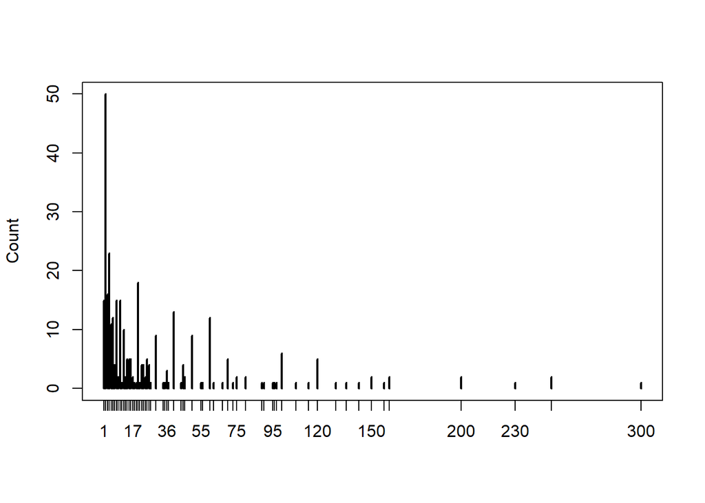

*Enicognathus ferrugineus* count frequencies

## Austral parakeet

### Estimating effective detection radius

We fit distance sampling models with different combinations of detection predictor variables:

Null model:

```
##
## Call:
## cmulti(formula = Y | D ~ 1, type = "dis")
##
## Distance Sampling (half-normal, circular area)
## Conditional Maximum Likelihood estimates
##
## Coefficients:
##                     Estimate Std. Error z value Pr(>|z|)
## log.tau_(Intercept)  4.64026    0.02754   168.5   <2e-16 ***
## ---
## Signif. codes:  0 '***' 0.001 '**' 0.01 '*' 0.05 '.' 0.1 ' ' 1
##
## Log-likelihood: -718.1
## BIC =  1441
```

Average group size (`gavg`) as predictor:

```
##
## Call:
## cmulti(formula = Y | D ~ gavg, data = X, type = "dis")
##
## Distance Sampling (half-normal, circular area)
## Conditional Maximum Likelihood estimates
##
## Coefficients:
##                       Estimate Std. Error z value Pr(>|z|)
## log.tau_(Intercept)  4.6621538  0.0351654 132.578   <2e-16 ***
## log.tau_gavg        -0.0007583  0.0007314  -1.037      0.3
## ---
## Signif. codes:  0 '***' 0.001 '**' 0.01 '*' 0.05 '.' 0.1 ' ' 1
##
## Log-likelihood: -717.6
## BIC =  1446
```

Number of pairs (`pair`) as predictor:

```
##
## Call:
## cmulti(formula = Y | D ~ pair, data = X, type = "dis")
##
## Distance Sampling (half-normal, circular area)
## Conditional Maximum Likelihood estimates
##
## Coefficients:
##                     Estimate Std. Error z value Pr(>|z|)
## log.tau_(Intercept)  4.65109    0.03191 145.748   <2e-16 ***
## log.tau_pair        -0.03420    0.04914  -0.696    0.486
## ---
## Signif. codes:  0 '***' 0.001 '**' 0.01 '*' 0.05 '.' 0.1 ' ' 1
##
## Log-likelihood: -717.8
## BIC =  1446
```

Number of groups (`ngroups`) as predictor:

```
##
## Call:
## cmulti(formula = Y | D ~ ngroups, data = X, type = "dis")
##
## Distance Sampling (half-normal, circular area)
## Conditional Maximum Likelihood estimates
##
## Coefficients:
##                       Estimate Std. Error z value Pr(>|z|)
## log.tau_(Intercept)  4.6406589  0.0425448 109.077   <2e-16 ***
## log.tau_ngroups     -0.0001171  0.0127876  -0.009    0.993
## ---
## Signif. codes:  0 '***' 0.001 '**' 0.01 '*' 0.05 '.' 0.1 ' ' 1
##
## Log-likelihood: -718.1
## BIC =  1447
```

Habitat type (`Urban` and `Agropastoral`, with other natural vegetation as baseline level) as predictor:

```
##
## Call:
## cmulti(formula = Y | D ~ Urban + Agropastoral, data = X, type = "dis")
##
## Distance Sampling (half-normal, circular area)
## Conditional Maximum Likelihood estimates
##
## Coefficients:
##                      Estimate Std. Error z value Pr(>|z|)
## log.tau_(Intercept)   4.58872    0.03844 119.365   <2e-16 ***
## log.tau_Urban         0.05744    0.05814   0.988   0.3232
## log.tau_Agropastoral  0.26269    0.10278   2.556   0.0106 *
## ---
## Signif. codes:  0 '***' 0.001 '**' 0.01 '*' 0.05 '.' 0.1 ' ' 1
##
## Log-likelihood: -714.3
## BIC =  1444
```

AIC table

|  | df | AIC | dAIC |
| --- | --- | --- | --- |
| m5 | 3 | 1434.532 | 0.00 |
| m1 | 1 | 1438.166 | 3.63 |
| m2 | 2 | 1439.144 | 4.61 |
| m3 | 2 | 1439.692 | 5.16 |
| m4 | 2 | 1440.166 | 5.63 |

Habitat type affects the effective detection radius (EDR). Specifically, detection radius is higher in agropastoral than urban and oterh habitats:

Effective detection radius (EDR)

| Habitat | EDR |
| --- | --- |
| Other | 98.36847 |
| Urban | 104.18432 |
| Agropastoral | 127.92056 |

We then model the number of groups as a function of covariates. The model for number of groups is G<sub>i</sub> ~ Poisson(D<sub>i</sub>A<sub>i</sub>), where D<sub>i</sub> = covariates and A<sub>i</sub> = area sampled in site. A<sub>i</sub> is calculated using the estimated EDR.

Models with habitat and quadratic effect of elevation:

```
##
## Call:
## glm(formula = ngroups ~ habitat, family = poisson, data = sites,
##     offset = log(sites$A))
##
## Deviance Residuals:
##     Min       1Q   Median       3Q      Max
## -3.1493  -0.3798  -0.2244  -0.1333   7.9159
##
## Coefficients:
##              Estimate Std. Error z value Pr(>|z|)
## (Intercept)   -4.3030     0.1826 -23.568   <2e-16 ***
## habitatOther   1.7168     0.1979   8.677   <2e-16 ***
## habitatUrban   2.3974     0.2020  11.870   <2e-16 ***
## ---
## Signif. codes:  0 '***' 0.001 '**' 0.01 '*' 0.05 '.' 0.1 ' ' 1
##
## (Dispersion parameter for poisson family taken to be 1)
##
##     Null deviance: 1865.3  on 2900  degrees of freedom
## Residual deviance: 1657.4  on 2898  degrees of freedom
## AIC: 2133.7
##
## Number of Fisher Scoring iterations: 7
```

```
## Analysis of Deviance Table
##
## Model: poisson, link: log
##
## Response: ngroups
##
## Terms added sequentially (first to last)
##
##
##         Df Deviance Resid. Df Resid. Dev
## NULL                     2900     1865.3
## habitat  2   207.97      2898     1657.4
```

```
##
## Call:
## glm(formula = ngroups ~ elevation + I(elevation^2), family = poisson,
##     data = sites, offset = log(sites$A))
##
## Deviance Residuals:
##     Min       1Q   Median       3Q      Max
## -3.1480  -0.3817  -0.2269  -0.1359   8.1569
##
## Coefficients:
##                  Estimate Std. Error z value Pr(>|z|)
## (Intercept)    -1.623e+00  1.353e-01 -11.992  < 2e-16 ***
## elevation      -4.514e-03  5.462e-04  -8.265  < 2e-16 ***
## I(elevation^2)  3.202e-06  4.366e-07   7.335 2.22e-13 ***
## ---
## Signif. codes:  0 '***' 0.001 '**' 0.01 '*' 0.05 '.' 0.1 ' ' 1
##
## (Dispersion parameter for poisson family taken to be 1)
##
##     Null deviance: 1865.3  on 2900  degrees of freedom
## Residual deviance: 1799.2  on 2898  degrees of freedom
## AIC: 2275.6
##
## Number of Fisher Scoring iterations: 7
```

```
## Analysis of Deviance Table
##
## Model: poisson, link: log
##
## Response: ngroups
##
## Terms added sequentially (first to last)
##
##
##                Df Deviance Resid. Df Resid. Dev
## NULL                            2900     1865.3
## elevation       1   15.876      2899     1849.5
## I(elevation^2)  1   50.242      2898     1799.2
```

```
##
## Call:
## glm(formula = ngroups ~ habitat + elevation + I(elevation^2),
##     family = poisson, data = sites, offset = log(sites$A))
##
## Deviance Residuals:
##     Min       1Q   Median       3Q      Max
## -3.1559  -0.3706  -0.2126  -0.1227   8.0062
##
## Coefficients:
##                  Estimate Std. Error z value Pr(>|z|)
## (Intercept)    -3.108e+00  2.327e-01 -13.356  < 2e-16 ***
## habitatOther    1.507e+00  2.021e-01   7.455 8.99e-14 ***
## habitatUrban    2.390e+00  2.021e-01  11.823  < 2e-16 ***
## elevation      -4.067e-03  5.784e-04  -7.032 2.04e-12 ***
## I(elevation^2)  2.775e-06  4.666e-07   5.947 2.73e-09 ***
## ---
## Signif. codes:  0 '***' 0.001 '**' 0.01 '*' 0.05 '.' 0.1 ' ' 1
##
## (Dispersion parameter for poisson family taken to be 1)
##
##     Null deviance: 1865.3  on 2900  degrees of freedom
## Residual deviance: 1602.6  on 2896  degrees of freedom
## AIC: 2083
##
## Number of Fisher Scoring iterations: 7
```

```
## Analysis of Deviance Table
##
## Model: poisson, link: log
##
## Response: ngroups
##
## Terms added sequentially (first to last)
##
##
##                Df Deviance Resid. Df Resid. Dev
## NULL                            2900     1865.3
## habitat         2  207.965      2898     1657.4
## elevation       1   21.279      2897     1636.1
## I(elevation^2)  1   33.475      2896     1602.6
```

AIC table

|  | df | AIC | dAIC |
| --- | --- | --- | --- |
| ngroup.hab.ele | 5 | 2082.963 | 0.00 |
| ngroup.hab | 3 | 2133.717 | 50.75 |
| ngroup.ele | 3 | 2275.565 | 192.60 |

Adding within-year temporal covariates (season and julian data) and their interactions with habitat

```
##
## Call:
## glm(formula = ngroups ~ habitat + elevation + I(elevation^2) +
##     season, family = poisson, data = sites, offset = log(sites$A))
##
## Deviance Residuals:
##     Min       1Q   Median       3Q      Max
## -3.1472  -0.3692  -0.2153  -0.1244   7.8798
##
## Coefficients:
##                      Estimate Std. Error z value Pr(>|z|)
## (Intercept)        -4.250e+00  4.119e-01 -10.318  < 2e-16 ***
## habitatOther        1.510e+00  2.037e-01   7.411 1.25e-13 ***
## habitatUrban        2.314e+00  2.026e-01  11.424  < 2e-16 ***
## elevation          -3.800e-03  5.929e-04  -6.408 1.47e-10 ***
## I(elevation^2)      2.565e-06  4.781e-07   5.365 8.11e-08 ***
## seasonnon-breeding  1.175e+00  3.404e-01   3.451 0.000558 ***
## ---
## Signif. codes:  0 '***' 0.001 '**' 0.01 '*' 0.05 '.' 0.1 ' ' 1
##
## (Dispersion parameter for poisson family taken to be 1)
##
##     Null deviance: 1865.3  on 2900  degrees of freedom
## Residual deviance: 1585.2  on 2895  degrees of freedom
## AIC: 2067.6
##
## Number of Fisher Scoring iterations: 7
```

```
##
## Call:
## glm(formula = ngroups ~ habitat + elevation + I(elevation^2) +
##     jdate, family = poisson, data = sites, offset = log(sites$A))
##
## Deviance Residuals:
##     Min       1Q   Median       3Q      Max
## -3.2214  -0.3724  -0.2107  -0.1227   7.9164
##
## Coefficients:
##                  Estimate Std. Error z value Pr(>|z|)
## (Intercept)    -3.012e+00  2.714e-01 -11.097  < 2e-16 ***
## habitatOther    1.508e+00  2.022e-01   7.460 8.67e-14 ***
## habitatUrban    2.376e+00  2.031e-01  11.700  < 2e-16 ***
## elevation      -4.053e-03  5.794e-04  -6.994 2.67e-12 ***
## I(elevation^2)  2.763e-06  4.675e-07   5.911 3.41e-09 ***
## jdate          -4.142e-04  6.014e-04  -0.689    0.491
## ---
## Signif. codes:  0 '***' 0.001 '**' 0.01 '*' 0.05 '.' 0.1 ' ' 1
##
## (Dispersion parameter for poisson family taken to be 1)
##
##     Null deviance: 1865.3  on 2900  degrees of freedom
## Residual deviance: 1602.1  on 2895  degrees of freedom
## AIC: 2084.5
##
## Number of Fisher Scoring iterations: 7
```

```
##
## Call:
## glm(formula = ngroups ~ elevation + I(elevation^2) + habitat *
##     season, family = poisson, data = sites, offset = log(sites$A))
##
## Deviance Residuals:
##     Min       1Q   Median       3Q      Max
## -3.1791  -0.3703  -0.2113  -0.1192   7.9062
##
## Coefficients:
##                                   Estimate Std. Error z value Pr(>|z|)
## (Intercept)                     -1.819e+01  5.580e+02  -0.033    0.974
## elevation                       -3.900e-03  5.957e-04  -6.547 5.88e-11 ***
## I(elevation^2)                   2.637e-06  4.795e-07   5.500 3.80e-08 ***
## habitatOther                     1.580e+01  5.580e+02   0.028    0.977
## habitatUrban                     2.008e+00  9.084e+02   0.002    0.998
## seasonnon-breeding               1.519e+01  5.580e+02   0.027    0.978
## habitatOther:seasonnon-breeding -1.436e+01  5.580e+02  -0.026    0.979
## habitatUrban:seasonnon-breeding  2.663e-01  9.084e+02   0.000    1.000
## ---
## Signif. codes:  0 '***' 0.001 '**' 0.01 '*' 0.05 '.' 0.1 ' ' 1
##
## (Dispersion parameter for poisson family taken to be 1)
##
##     Null deviance: 1865.3  on 2900  degrees of freedom
## Residual deviance: 1579.2  on 2893  degrees of freedom
## AIC: 2065.6
##
## Number of Fisher Scoring iterations: 16
```

```
##
## Call:
## glm(formula = ngroups ~ elevation + I(elevation^2) + habitat *
##     jdate, family = poisson, data = sites, offset = log(sites$A))
##
## Deviance Residuals:
##     Min       1Q   Median       3Q      Max
## -2.9320  -0.3706  -0.2105  -0.1220   7.5882
##
## Coefficients:
##                      Estimate Std. Error z value Pr(>|z|)
## (Intercept)        -3.059e+00  5.367e-01  -5.700 1.20e-08 ***
## elevation          -4.031e-03  5.806e-04  -6.943 3.83e-12 ***
## I(elevation^2)      2.713e-06  4.683e-07   5.792 6.94e-09 ***
## habitatOther        1.917e+00  5.549e-01   3.455 0.000549 ***
## habitatUrban        2.037e+00  5.630e-01   3.618 0.000297 ***
## jdate              -1.865e-04  1.989e-03  -0.094 0.925267
## habitatOther:jdate -1.714e-03  2.151e-03  -0.797 0.425710
## habitatUrban:jdate  1.624e-03  2.210e-03   0.735 0.462245
## ---
## Signif. codes:  0 '***' 0.001 '**' 0.01 '*' 0.05 '.' 0.1 ' ' 1
##
## (Dispersion parameter for poisson family taken to be 1)
##
##     Null deviance: 1865.3  on 2900  degrees of freedom
## Residual deviance: 1595.2  on 2893  degrees of freedom
## AIC: 2081.5
##
## Number of Fisher Scoring iterations: 7
```

AIC table

[output not shown]

Adding year covariate

```
##
## Call:
## glm(formula = ngroups ~ habitat + elevation + I(elevation^2) +
##     season + year, family = poisson, data = sites, offset = log(sites$A))
##
## Deviance Residuals:
##     Min       1Q   Median       3Q      Max
## -2.9215  -0.3997  -0.2281  -0.1296   7.0783
##
## Coefficients:
##                      Estimate Std. Error z value Pr(>|z|)
## (Intercept)        -6.612e+02  1.162e+02  -5.689 1.28e-08 ***
## habitatOther        1.683e+00  2.058e-01   8.182 2.80e-16 ***
## habitatUrban        2.397e+00  2.030e-01  11.808  < 2e-16 ***
## elevation          -3.595e-03  5.980e-04  -6.011 1.84e-09 ***
## I(elevation^2)      2.369e-06  4.836e-07   4.899 9.62e-07 ***
## seasonnon-breeding  8.960e-01  3.439e-01   2.605  0.00919 **
## year                3.262e-01  5.770e-02   5.653 1.58e-08 ***
## ---
## Signif. codes:  0 '***' 0.001 '**' 0.01 '*' 0.05 '.' 0.1 ' ' 1
##
## (Dispersion parameter for poisson family taken to be 1)
##
##     Null deviance: 1865.3  on 2900  degrees of freedom
## Residual deviance: 1554.0  on 2894  degrees of freedom
## AIC: 2038.3
##
## Number of Fisher Scoring iterations: 7
```

AIC table

|  | df | AIC | dAIC |
| --- | --- | --- | --- |
| ngroup.hab.ele.season.year | 7 | 2038.307 | 0.00 |
| ngroup.hab.ele.season | 6 | 2067.555 | 29.25 |

```
## Analysis of Deviance Table
##
## Model: poisson, link: log
##
## Response: ngroups
##
## Terms added sequentially (first to last)
##
##
##                Df Deviance Resid. Df Resid. Dev
## NULL                            2900     1865.3
## habitat         2  207.965      2898     1657.4
## elevation       1   21.279      2897     1636.1
## I(elevation^2)  1   33.475      2896     1602.6
## season          1   17.408      2895     1585.2
## year            1   31.248      2894     1554.0
```

The model with year has a better fit.